# Model Selection and Model Checking (in Poisson Regression, and GLMs)

## Negative Binomial Regression

Negative Binomial is also a discrete distribution used to model counts. It can be parametrized in many ways but one convenient way is in terms of the mean $\mu$ and the dispersion parameter $\alpha$. In this parametrization, $Y \sim NB(\mu, \alpha)$ means that \begin{align*} \mathbb{P}(Y = y) = \frac{\alpha^y \Gamma(y + \alpha)}{\Gamma(\alpha)} \frac{\left(1 + \alpha \mu \right)^{-1/\alpha}}{y!}\left(\frac{\mu}{1 + \alpha \mu} \right)^y \end{align*} for $y = 0, 1, 2, \dots$. This is the distribution of the number of failures before the $k^{th}$ success where $k = 1/\alpha$ and the coin has success probability $p = (1 + \alpha \mu)^{-1}$. In general, $\alpha$ can be any positive real number and $1/\alpha$ need not be an integer.

The mean of $NB(\mu, \alpha)$ equals $\mu$ and the variance equals $\mu + \mu^2 \alpha$. When $\alpha \downarrow 0$, it can be shown that the above expression for $\mathbb{P}(Y = y)$ converges to $\frac{e^{-\mu}}{y!} \mu^y.$ Thus when $\alpha \approx 0$, the Negative Binomial Distribution $NB(\mu, \alpha)$ is essentially same as the Poisson distribution. The variance of $NB(\mu, \alpha)$ equals $\mu + \mu^2 \alpha$ so it exceeds the mean $\mu$. This is often referred to as OverDispersion. On the other hand, for the Poisson, there is no overdispersion as the mean and variance coincide (both equal $\mu$). The Negative Binomial Regression model is \begin{align*} \log \mu = \beta_0 + \beta_1 x_1 + \dots + \beta_m x_m. \end{align*} The above model specification coincides with that of Poisson Regression. Usually the parameter $\alpha$ is treated as unknown and is estimated together with $\beta_0, \dots, \beta_m$ via maximum likelihood.

There are two ways of fitting Negative Binomial Regression using statsmodels: the function `sm.GLM(Y, X, family = sm.families.NegativeBinomial()).fit()` and `sm.NegativeBinomial(Y, X).fit()`. The latter function also treats $\alpha$ as an unknown parameter and estimates it. The model output then also includes a row for the parameter $\alpha$. The former function expects to be given a value of $\alpha$ and takes $\alpha = 1$ as default if not supplied.

```python
#Negative Binomial Regression
Y = mroz['hours']
X = mroz[['kidslt6', 'age', 'educ', 'huswage', 'exper', 'expersq']]
X = sm.add_constant(X)  # Add a constant (intercept) to the model
# Fit the Negative Binomial regression model
#First Way:
negbinom_model = sm.NegativeBinomial(Y, X).fit() #this treats alpha as an unknown parameter and
#fits it giving an estimate (in this case 7.42).
# Display the summary
print(negbinom_model.summary())

#Second Way:
negbinom_model = sm.GLM(Y, X, family=sm.families.NegativeBinomial(alpha=7)).fit()
#I am giving alpha = 7 because it was basically the estimate of alpha that was given by sm.NegativeBinomial.
```

[output not shown]

```python
#The estimates of regression coefficients are different (compared to Poisson regression) but similar.
#The coefficient of kidslt6 now leads to the interpretation (note that the model is still log mu = b0 + b1 x1 + ... + bm xm)
print((np.exp(negbinom_model.params['kidslt6']) - 1)*100)
```

```
-64.46921135832466
```

```python
#Fitted values and their range
negbinom_fitted_values = negbinom_model.fittedvalues
print(f"Range of observed response: {[np.min(Y), np.max(Y)]}")
print(f"Range of fitted values for Poisson regression: {[np.min(poireg_fitted_values), np.max(poireg_fitted_values)]}")
print(f"Range of fitted values for Negative Binomial regression: {[np.min(negbinom_fitted_values), np.max(negbinom_fitted_values)]}")
#Note the bigger spread of values for the Negative Binomial Regression. This improves the issue of overdispersion.
```

```
Range of observed response: [0, 4950]
Range of fitted values for Poisson regression: [45.58196325662061, 2132.55829618613]
Range of fitted values for Negative Binomial regression: [20.113601308712315, 2846.983218999344]
```

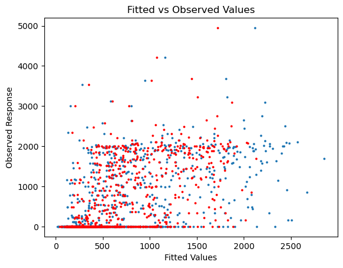

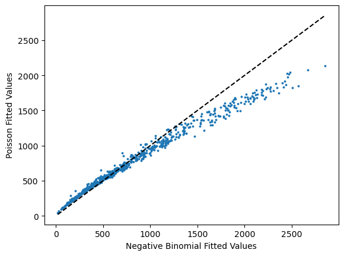

```python
#Plotting Fitted Values and Observed Response Values
plt.scatter(negbinom_fitted_values, Y, alpha = 1, s = 3)
plt.scatter(poireg_fitted_values, Y, alpha = 1, s = 3, color = 'red')
plt.xlabel('Fitted Values')
plt.ylabel('Observed Response')
plt.title('Fitted vs Observed Values')
plt.show()
#The negative binomial fits show more dispersion
plt.scatter(negbinom_fitted_values, poireg_fitted_values, alpha = 1, s = 3)
plt.xlabel('Negative Binomial Fitted Values')
plt.ylabel('Poisson Fitted Values')
x = np.linspace(min(negbinom_fitted_values), max(negbinom_fitted_values), 100)
plt.plot(x, x, label='y=x', linestyle='--', color='black')
plt.show()
```

One can plot the posterior predictive distributions (as in the case of Poisson regression) and compare the histograms with the actual response values (especially for the problematic cases with low or high responses). These histograms should be much closer to the actual responses compared to the corresponding plots for Poisson regression.

## Generalized Linear Models

We now look at the three regression models studied so far: linear regression, Poisson regression, Negative Binomial regression, as well as logistic regression (you may have studied logistic regression in a different course) together with a unified lens. These models can be written as follows:

1. Linear Regression. Response is modeled as $Y \sim N(\text{mean} = \mu, \text{variance} = \sigma^2)$. $\mu$ and the explanatory variables are connected via: $\mu = \beta_0 + \beta_1 x_1 + \dots + \beta_m x_m$.
2. Poisson Regression. Response is modeled as $Y \sim \text{Poisson}(\text{mean} = \mu)$. $\mu$ and the explanatory variables are connected via: $\log \mu = \beta_0 + \beta_1 x_1 + \dots + \beta_m x_m$, or equivalently $\mu = \exp \left( \beta_0 + \beta_1 x_1 + \dots + \beta_m x_m \right)$.
3. Logistic Regression. Response is modeled as $Y \sim \text{Bernoulli}(\text{mean} = \mu)$. $\mu$ and the explanatory variables are connected via: $\log \frac{\mu}{1-\mu} = \beta_0 + \beta_1 x_1 + \dots + \beta_m x_m$, or equivalently $\mu = \frac{\exp \left( \beta_0 + \beta_1 x_1 + \dots + \beta_m x_m \right)}{1 + \exp \left( \beta_0 + \beta_1 x_1 + \dots + \beta_m x_m \right)}$.
4. Negative Binomial Regression. Response is modeled as $Y \sim \text{Negative Binomial}(\text{mean} = \mu, \text{dispersion} = \alpha)$. $\mu$ and the explanatory variables are connected via: $\log \mu = \beta_0 + \beta_1 x_1 + \dots + \beta_m x_m$, or equivalently $\mu = \exp \left( \beta_0 + \beta_1 x_1 + \dots + \beta_m x_m \right)$.

Thus, in each of these models, we first have a modeling assumption for the response $Y$. Then the mean $\mu$ of $Y$ is connected to the covariates (or explanatory variables) as $g(\mu) = \beta_0 + \beta_1 x_1 + \dots + \beta_m x_m$. This function $g$ is called the link function and its inverse $g^{-1}$ is called the inverse link. For example, for logistic regression $g(\mu) = \log \frac{\mu}{1 - \mu}$ is the link function and $g^{-1}(z) = \frac{e^z}{1 + e^z}$ is the inverse link function.

Parameter estimation of $\beta$ is done by Maximum Likelihood typically using an iterative algorithm such as Newton's method. The posterior distribution of $\beta$ is approximated by the multivariate normal distribution centered at the MLE and covariance equalling the inverse of the negative Hessian of the log-likelihood evaluated at the MLE.